# Gulf of Maine Warming Update: 2024

Author

Adam Kemberling

Published

September 22, 2025

Over the past decade, scientists at the Gulf of Maine Research Institute have led a body of research that highlights the rapid pace of warming in the Gulf of Maine. To keep you informed, we share seasonal and annual updates about conditions in the Gulf of Maine.

## Annual Warming Trends in the Gulf of Maine

The precise causes of the pronounced jump in annual average SSTs in the region from 2009 to 2012 remains an area of active research, but the sustained warm conditions suggest a regime shift in the influence of major ocean currents (i.e., Gulf Stream vs Labrador Current) in the Gulf of Maine.

While a long-term increase in SSTs is expected as a result of human-caused climate change, we also expect each year to be influenced by large-scale patterns of natural variability, particularly on sub-global (i.e., regional) scales.

SST conditions in the Gulf of Maine for 2024 retain the region’s distinction as being one of the fastest warming ocean regions on the planet; including the 2024 data shows that the Gulf of Maine is warming faster than 97% of the world’s ocean surface.

[figure not shown]

## Comparing Annual SST to Historical Conditions

The annual average SST in the Gulf of Maine for 2024 (51.51°F) places it as the twelfth warmest year on record (Figure 2). This marks the third consecutive year of year-over-year declines in average temperatures, while still comfortably seated +0.88°F above the long-term average.

[figure not shown]

### Average Monthly Conditions

Table 1. Monthly Average Sea Surface Temperatures - 2024

| Month | Warm to Cold Ranking (1982-2024) | Observed Temperature | Climatological Average | Temperature Anomaly |
| --- | --- | --- | --- | --- |
| *January* | 25 | 42.6°F *(5.9°C)* | 43.5°F *(6.4°C)* | -0.9°F *(-0.5°C)* |
| *February* | 34 | 39.8°F *(4.3°C)* | 40.9°F *(4.9°C)* | -1.1°F *(-0.6°C)* |
| *March* | 16 | 40.7°F *(4.8°C)* | 40.1°F *(4.5°C)* | 0.6°F *(0.3°C)* |
| *April* | 11 | 42.9°F *(6.0°C)* | 41.8°F *(5.5°C)* | 1.0°F *(0.6°C)* |
| *May* | 8 | 48.1°F *(8.9°C)* | 46.5°F *(8.1°C)* | 1.5°F *(0.8°C)* |
| *June* | 2 | 56.6°F *(13.7°C)* | 53.5°F *(11.9°C)* | 3.1°F *(1.7°C)* |
| *July* | 11 | 61.9°F *(16.6°C)* | 60.5°F *(15.8°C)* | 1.4°F *(0.8°C)* |
| *August* | 11 | 64.8°F *(18.2°C)* | 63.2°F *(17.3°C)* | 1.6°F *(0.9°C)* |
| *September* | 10 | 62.8°F *(17.1°C)* | 61.2°F *(16.2°C)* | 1.6°F *(0.9°C)* |
| *October* | 7 | 58.6°F *(14.8°C)* | 56.7°F *(13.7°C)* | 1.9°F *(1.1°C)* |
| *November* | 16 | 52.2°F *(11.2°C)* | 51.7°F *(11.0°C)* | 0.5°F *(0.3°C)* |
| *December* | 25 | 46.7°F *(8.2°C)* | 47.5°F *(8.6°C)* | -0.8°F *(-0.5°C)* |

*Data Source: NOAA OISSTv2 Daily Sea Surface Temperature Data.*  
*Climatological Reference Period: 1991-2020.*

Table 1: Average monthly sea surface temperatures in the Gulf of Maine

## Daily SSTs in the Gulf of Maine

[figure not shown]

Figure 3: A timeseries of daily SSTs (January 1 through December 31, 2024) with an indication of marine heatwave (MHW) conditions in the Gulf of Maine. Black lines represent the long-term (i.e., 1991 – 2020) average SST, the 10th percentile (i.e., cold spell threshold), and 90th percentile (i.e., heatwave threshold). A solid line indicates the observed SST for each day; red and blue shading illustrates whether each day is considered part of a MHW event.

### SST Anomalis & MHW Events

[figure not shown]

Figure 4: A timeseries of marine heatwave (MHW) conditions in the Gulf of Maine extending from January 1, 2024 through December 31, 2024. The black line represents the long-term (i.e., 1991 – 2020) average SST. The 10th to 90th percentile range is shaded in gray. The heavy line (red for marine heatwave or blue for a non-event) indicates the observed SST this year.

### Gulf of Maine SST Heatmap

Since 2010 the Gulf of Maine has experienced a disproportionate number of anomalously hot SSTs and prolonged MHW events. Cooler than average SSTs during this period are rare, but examples of cooler periods can be found (ex. 2019).

[figure not shown]

Figure 5: Heat map of daily SST anomalies from the beginning of 1982 through the end of 2024. Not only do more large warm anomalies (darker reds) appear more frequently in recent years, but the frequency and duration of marine heatwave events (black lines) in the Gulf of Maine has become more pronounced in the past decade.

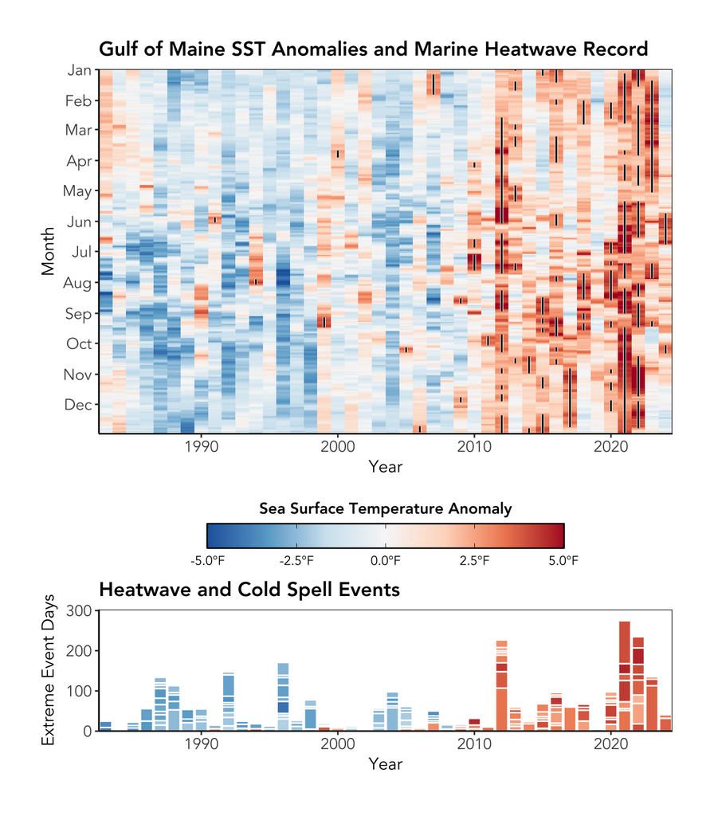